# Analyzing Bay Wheels's trip data

## by Kyungjin Cho

## Investigation Overview

> In this investigation, I wanted to observe characteristics of using patterns of the bay Area bike share system. The main focus was figuring out differences in using patterns among diverse user types.

## Dataset Overview

> This document explores the Bay Wheels's trip data for public use containing over 230,000 bike rides. This data was modified on the 6th of November, 2019. There are about 239,895 bike rides in the dataset with 17 features.

> •duration: duration_sec, start_time, end_time  
> •stations(start/end): id, name, latitude, longitude  
> •user: bike_id, user_type, birty_year, gender, age  
> •bike share: bike_share_for_all_trip

> However, some of them are removed because of the inconsistency in the birth date, which in some cases was dated prior 1900.

## Trip Duration (per user type)

> When I analyzed distribution time of this bike sharing service per user type, I could find out the difference. In general, trip durations are longer for **customers** than **subscribers**. We can guess that it's because of the fact that **customers** prefer longer trips and weekend bike riding. On the other hand, we can expect that **subscribers** probably use this system mainly for commuting.

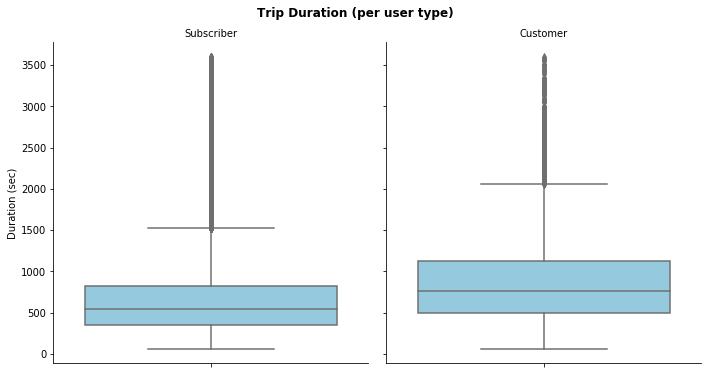

```python
# Distribution time of the bike sharing system per user type
data = df_clean.query('duration_sec < 3600')
g = sns.catplot(data=data, y='duration_sec', col="user_type", kind='box',
            color = 'skyblue')
g.set_titles(col_template = '{col_name}')
g.set_axis_labels("", "Duration (sec)")
g.fig.suptitle('Trip Duration (per user type)', y=1.03, fontsize=12, fontweight='bold');
```

## Features of Users (per gender and user type)

> When we look at this bar chart, we can know that **men** are using this system more often than **women** and others (the registration system allows you to choose 'Other' as a gender). However, the ratio is much smaller between **men** and **women** for customers than for subscribers. Each ratio is 2:1 and 3:1. Also, this bike sharing service is mainly used by **subscribers**. About 95.9% of users are **subscribers** while 4.1% of users are **customers**.

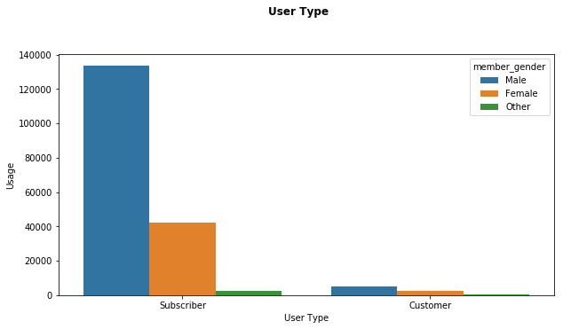

```python
# Create a bar chart
plt.figure(figsize = [10, 5])
g = sns.countplot(data=df_clean, x="user_type", hue="member_gender", order=df_clean.user_type.value_counts().index)
g.set_xlabel('User Type')
g.set_ylabel('Usage');

plt.suptitle('User Type', y=1.03, fontsize=12, fontweight='bold');
```

## Hourly and Weekly Usage of Each User Type

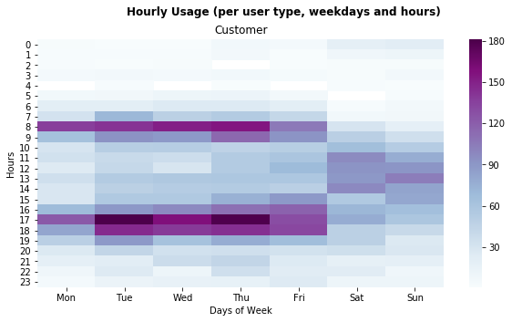

```python
#For customers
plt.figure(figsize = [10, 5])
sns.heatmap(df_customer, cmap="BuPu")
plt.title("Customer", y=1.015)
plt.xlabel('Days of Week')
plt.ylabel('Hours')
plt.suptitle('Hourly Usage (per user type, weekdays and hours)', fontsize=12, fontweight='bold')
```

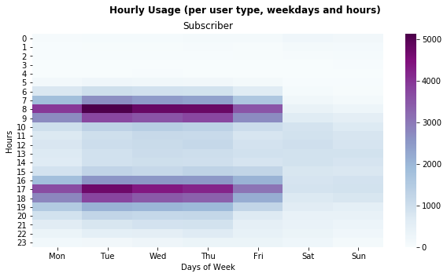

```python
# For subscribers
plt.figure(figsize = [10, 5])
sns.heatmap(df_subscriber, cmap="BuPu")
plt.title("Subscriber", y=1.015)
plt.xlabel('Days of Week')
plt.ylabel('Hours')
plt.suptitle('Hourly Usage (per user type, weekdays and hours)', fontsize=12, fontweight='bold')
```